# balance Quickstart: New API (SampleFrame / BalanceFrame)

This tutorial demonstrates the **new** `SampleFrame` + `BalanceFrame` API introduced in balance 0.18.0. It mirrors the original `balance_quickstart.ipynb` step-by-step, but uses **only** the new classes — no `Sample` object is needed.

### Why a new API?

| Old API (`Sample`) | New API (`SampleFrame` / `BalanceFrame`) |
| --- | --- |
| Column roles inferred by exclusion | Column roles declared explicitly |
| Mutable `.set_target()` / `.adjust()` | Immutable — `adjust()` returns a **new** object |
| One class does everything | Clear separation: data container vs. adjustment orchestrator |
| Weight provenance not tracked | Weight metadata recorded per-column |

The old `Sample` API still works and is fully supported; this notebook simply shows how to do the same analysis with the new classes.

## Analysis

There are four main steps to analysis with the new API:

1. Load data into pandas DataFrames
2. Create `SampleFrame` objects with explicit column roles
3. Build a `BalanceFrame`, adjust, and inspect diagnostics
4. Output results (CSV, download)

## Example dataset

The following is a toy simulated dataset (same data used in the original quickstart).

```python
%matplotlib inline

import warnings
warnings.filterwarnings("ignore")

from balance import load_data

target_df, sample_df = load_data()

print("target_df: \n", target_df.head())
print("sample_df: \n", sample_df.head())
```

```
INFO (2026-09-21 04:47:30,763) [__init__/<module> (line 76)]: Using balance version 0.23.0
```

[output not shown]

```
target_df:
        id gender age_group     income  happiness
0  100000   Male       45+  10.183951  61.706333
1  100001   Male       45+   6.036858  79.123670
2  100002   Male     35-44   5.226629  44.206949
3  100003    NaN       45+   5.752147  83.985716
4  100004    NaN     25-34   4.837484  49.339713
sample_df:
   id  gender age_group     income  happiness
0  0    Male     25-34   6.428659  26.043029
1  1  Female     18-24   9.940280  66.885485
2  2    Male     18-24   2.673623  37.091922
3  3     NaN     18-24  10.550308  49.394050
4  4     NaN     18-24   2.689994  72.304208
```

In practice, you can use `pandas.read_csv()` (or any pandas loader) to import your own data. The new API also provides `SampleFrame.from_csv()` for a one-step shortcut.

## Load data into SampleFrame objects

With the old API you would call `Sample.from_frame(df)`. The new API uses `SampleFrame.from_frame()` where you **explicitly** declare which columns are covariates, outcomes, etc. If you omit these arguments, the factory auto-detects roles the same way `Sample` does (by exclusion from the id and weight columns).

```python
from balance import SampleFrame, BalanceFrame
```

```python
sample_sf = SampleFrame.from_frame(
    sample_df,
    outcome_columns=["happiness"],
)
# Often times we don't have the outcome for the target.
# In this case we've added it just to validate later that
# the weights indeed help us reduce the bias.
target_sf = SampleFrame.from_frame(
    target_df,
    outcome_columns=["happiness"],
)
```

```
WARNING (2026-09-21 04:47:30,813) [input_validation/guess_id_column (line 335)]: Guessed id column name id for the data
```

```
WARNING (2026-09-21 04:47:30,824) [sample_frame/from_frame (line 379)]: No weights passed. Adding a 'weight' column and setting all values to 1
```

```
WARNING (2026-09-21 04:47:30,826) [input_validation/guess_id_column (line 335)]: Guessed id column name id for the data
```

```
WARNING (2026-09-21 04:47:30,840) [sample_frame/from_frame (line 379)]: No weights passed. Adding a 'weight' column and setting all values to 1
```

### Inspecting a SampleFrame

You can inspect the column roles and data shape at any time. Unlike `Sample.df`, each role is a separate property — no magic "everything-that's-left" inference.

```python
print(f"Covariates:  {sample_sf.covar_columns}")
print(f"Outcomes:    {sample_sf.outcome_columns}")
print(f"Weight cols: {sample_sf.weight_columns_all}")
print(f"Active wt:   {sample_sf.weight_column}")
print(f"ID column:   {sample_sf._id_column_name}")
print(f"Rows:        {len(sample_sf)}")
```

```
Covariates:  ['gender', 'age_group', 'income']
Outcomes:    ['happiness']
Weight cols: ['weight']
Active wt:   weight
ID column:   id
Rows:        1000
```

```python
sample_sf.df.info()
```

```
<class 'pandas.DataFrame'>
RangeIndex: 1000 entries, 0 to 999
Data columns (total 6 columns):
 #   Column     Non-Null Count  Dtype
---  ------     --------------  -----
 0   id         1000 non-null   str
 1   gender     912 non-null    str
 2   age_group  1000 non-null   str
 3   income     1000 non-null   float64
 4   happiness  1000 non-null   float64
 5   weight     1000 non-null   float64
dtypes: float64(3), str(3)
memory usage: 47.0 KB
```

```python
print(sample_sf)
print(target_sf)
```

```
SampleFrame: 1000 observations x 3 covariates: gender,age_group,income
  id_column: id, weight_columns_all: ['weight'], outcome_columns: happiness
SampleFrame: 10000 observations x 3 covariates: gender,age_group,income
  id_column: id, weight_columns_all: ['weight'], outcome_columns: happiness
```

## Create a BalanceFrame

With the old API you would call `sample.set_target(target)`. The new API constructs a `BalanceFrame` directly from two `SampleFrame` objects.

A `BalanceFrame` is **immutable** — `adjust()` returns a *new* BalanceFrame rather than mutating the existing one.

```python
bf = BalanceFrame(sample=sample_sf, target=target_sf)
print(bf)
```

```
        balance Sample object with target set
        1000 observations x 3 variables: gender,age_group,income
        id_column: id, weight_column: weight,
        outcome_columns: happiness

            target:
                 SampleFrame: 10000 observations x 3 covariates: gender,age_group,income
	  id_column: id, weight_columns_all: ['weight'], outcome_columns: happiness
            3 common variables: gender,age_group,income
```

## Pre-Adjustment Diagnostics

The `.covars()`, `.weights()`, and `.outcomes()` methods return the same `BalanceDFCovars` / `BalanceDFWeights` / `BalanceDFOutcomes` objects as the old API. All of `.mean()`, `.asmd()`, `.plot()`, etc. work identically.

```python
print(bf.covars().mean().T)
```

```
source                     self     target
_is_na_gender[T.True]  0.088000   0.089800
age_group[T.25-34]     0.300000   0.297400
age_group[T.35-44]     0.156000   0.299200
age_group[T.45+]       0.053000   0.206300
gender[Female]         0.268000   0.455100
gender[Male]           0.644000   0.455100
gender[_NA]            0.088000   0.089800
income                 6.297302  12.737608
```

```python
print(bf.covars().asmd().T)
```

```
source                  self
age_group[T.25-34]  0.005688
age_group[T.35-44]  0.312711
age_group[T.45+]    0.378828
gender[Female]      0.375699
gender[Male]        0.379314
gender[_NA]         0.006296
income              0.494217
mean(asmd)          0.326799
```

```python
print(bf.covars().asmd(aggregate_by_main_covar=True).T)
```

```
source          self
age_group   0.232409
gender      0.253769
income      0.494217
mean(asmd)  0.326799
```

### Visualizing the unadjusted comparison

```python
bf.covars().plot()
```

## Adjusting Sample to Population

The default method is `'ipw'` (inverse probability/propensity weights via logistic regression with lasso regularization).

**Key difference from the old API:** `adjust()` returns a **new** `BalanceFrame` — the original `bf` is unchanged.

```python
adjusted = bf.adjust()
print(adjusted)
```

```
INFO (2026-09-21 04:47:34,765) [ipw/ipw (line 734)]: Starting ipw function
```

```
INFO (2026-09-21 04:47:34,770) [adjustment/apply_transformations (line 438)]: Adding the variables: []
```

```
INFO (2026-09-21 04:47:34,771) [adjustment/apply_transformations (line 439)]: Transforming the variables: ['gender', 'age_group', 'income']
```

```
INFO (2026-09-21 04:47:34,779) [adjustment/apply_transformations (line 475)]: Final variables in output: ['gender', 'age_group', 'income']
```

```
INFO (2026-09-21 04:47:34,900) [ipw/ipw (line 811)]: Building model matrix
```

```
INFO (2026-09-21 04:47:34,901) [ipw/ipw (line 812)]: The formula used to build the model matrix: ['income + gender + age_group + _is_na_gender']
```

```
INFO (2026-09-21 04:47:34,901) [ipw/ipw (line 813)]: The number of columns in the model matrix: 16
```

```
INFO (2026-09-21 04:47:34,902) [ipw/ipw (line 814)]: The number of rows in the model matrix: 11000
```

```
INFO (2026-09-21 04:47:54,563) [ipw/ipw (line 1016)]: Done with sklearn
```

```
INFO (2026-09-21 04:47:54,564) [ipw/ipw (line 1018)]: max_de: None
```

```
INFO (2026-09-21 04:47:54,565) [ipw/ipw (line 1040)]: Starting model selection
```

```
INFO (2026-09-21 04:47:54,567) [ipw/ipw (line 1096)]: Chosen lambda: 0.041158338186664825
```

```
INFO (2026-09-21 04:47:54,568) [ipw/ipw (line 1113)]: Proportion null deviance explained 0.172637976731583
```

```
        Adjusted balance Sample object with target set using ipw
        1000 observations x 3 variables: gender,age_group,income,weight_pre_adjust,weight_adjusted_1
        id_column: id, weight_column: weight,
        outcome_columns: happiness

        adjustment details:
            method: ipw
            weight trimming mean ratio: 20
            design effect (Deff): 1.880
            effective sample size proportion (ESSP): 0.532
            effective sample size (ESS): 531.9

            target:
                 SampleFrame: 10000 observations x 3 covariates: gender,age_group,income
	  id_column: id, weight_columns_all: ['weight'], outcome_columns: happiness
            3 common variables: gender,age_group,income
```

```python
# The original is still unadjusted:
print(f"bf.is_adjusted        = {bf.is_adjusted}")
print(f"adjusted.is_adjusted  = {adjusted.is_adjusted}")
```

```
bf.is_adjusted        = False
adjusted.is_adjusted  = True
```

## Sklearn-style fit / design_matrix / predict_proba workflow

For IPW, `fit(method="ipw")` stores fit-time matrices and metadata by default, so you can reuse design matrices, propensity predictions, and reproduced weights without re-running model preprocessing.

```python
import numpy as np

fitted = bf.fit(method="ipw", inplace=False)
x_sample, x_target = fitted.design_matrix(on="both")
p_target = fitted.predict_proba(on="target", output="probability")
w_reproduced = fitted.predict_weights()

print("Sample matrix shape:", x_sample.shape)
print("Target matrix shape:", x_target.shape)
print("Target propensity rows:", p_target.shape[0])
print(
    "Reproduced weights match fitted weights:",
    np.allclose(w_reproduced.to_numpy(), fitted.weight_series.to_numpy()),
)
```

```
INFO (2026-09-21 04:47:54,607) [ipw/ipw (line 734)]: Starting ipw function
```

```
INFO (2026-09-21 04:47:54,612) [adjustment/apply_transformations (line 438)]: Adding the variables: []
```

```
INFO (2026-09-21 04:47:54,613) [adjustment/apply_transformations (line 439)]: Transforming the variables: ['gender', 'age_group', 'income']
```

```
INFO (2026-09-21 04:47:54,622) [adjustment/apply_transformations (line 475)]: Final variables in output: ['gender', 'age_group', 'income']
```

```
INFO (2026-09-21 04:47:54,756) [ipw/ipw (line 811)]: Building model matrix
```

```
INFO (2026-09-21 04:47:54,757) [ipw/ipw (line 812)]: The formula used to build the model matrix: ['income + gender + age_group + _is_na_gender']
```

```
INFO (2026-09-21 04:47:54,758) [ipw/ipw (line 813)]: The number of columns in the model matrix: 16
```

```
INFO (2026-09-21 04:47:54,758) [ipw/ipw (line 814)]: The number of rows in the model matrix: 11000
```

```
INFO (2026-09-21 04:48:14,429) [ipw/ipw (line 1016)]: Done with sklearn
```

```
INFO (2026-09-21 04:48:14,431) [ipw/ipw (line 1018)]: max_de: None
```

```
INFO (2026-09-21 04:48:14,432) [ipw/ipw (line 1040)]: Starting model selection
```

```
INFO (2026-09-21 04:48:14,437) [ipw/ipw (line 1096)]: Chosen lambda: 0.041158338186664825
```

```
INFO (2026-09-21 04:48:14,438) [ipw/ipw (line 1113)]: Proportion null deviance explained 0.172637976731583
```

```
Sample matrix shape: (1000, 16)
Target matrix shape: (10000, 16)
Target propensity rows: 10000
Reproduced weights match fitted weights: True
```

### Fit on a subset, apply on the rest

You can fit IPW on a training subset and then attach that fitted model to a holdout `BalanceFrame` via `set_fitted_model(..., inplace=False)`.

```python
train_n = 700

train_sample_sf = SampleFrame.from_frame(sample_df.iloc[:train_n].copy())
holdout_sample_sf = SampleFrame.from_frame(sample_df.iloc[train_n:].copy())
train_target_sf = SampleFrame.from_frame(target_df.iloc[:7000].copy())
holdout_target_sf = SampleFrame.from_frame(target_df.iloc[7000:].copy())

train_bf = BalanceFrame(sample=train_sample_sf, target=train_target_sf)
holdout_bf = BalanceFrame(sample=holdout_sample_sf, target=holdout_target_sf)

fitted_train = train_bf.fit(method="ipw", inplace=False)
scored_holdout = holdout_bf.set_fitted_model(fitted_train)

holdout_matrix = scored_holdout.design_matrix(on="sample")
holdout_propensity = scored_holdout.predict_proba(on="sample", output="probability")
holdout_weights = scored_holdout.predict_weights()

print("Holdout matrix shape:", holdout_matrix.shape)
print("Holdout propensity rows:", holdout_propensity.shape[0])
print("Holdout weights rows:", holdout_weights.shape[0])
```

```
WARNING (2026-09-21 04:48:14,461) [input_validation/guess_id_column (line 335)]: Guessed id column name id for the data
```

```
WARNING (2026-09-21 04:48:14,476) [sample_frame/from_frame (line 379)]: No weights passed. Adding a 'weight' column and setting all values to 1
```

```
WARNING (2026-09-21 04:48:14,478) [input_validation/guess_id_column (line 335)]: Guessed id column name id for the data
```

```
WARNING (2026-09-21 04:48:14,491) [sample_frame/from_frame (line 379)]: No weights passed. Adding a 'weight' column and setting all values to 1
```

```
WARNING (2026-09-21 04:48:14,493) [input_validation/guess_id_column (line 335)]: Guessed id column name id for the data
```

```
WARNING (2026-09-21 04:48:14,511) [sample_frame/from_frame (line 379)]: No weights passed. Adding a 'weight' column and setting all values to 1
```

```
WARNING (2026-09-21 04:48:14,515) [input_validation/guess_id_column (line 335)]: Guessed id column name id for the data
```

```
WARNING (2026-09-21 04:48:14,530) [sample_frame/from_frame (line 379)]: No weights passed. Adding a 'weight' column and setting all values to 1
```

```
INFO (2026-09-21 04:48:14,537) [ipw/ipw (line 734)]: Starting ipw function
```

```
INFO (2026-09-21 04:48:14,542) [adjustment/apply_transformations (line 438)]: Adding the variables: []
```

```
INFO (2026-09-21 04:48:14,543) [adjustment/apply_transformations (line 439)]: Transforming the variables: ['gender', 'age_group', 'income', 'happiness']
```

```
INFO (2026-09-21 04:48:14,553) [adjustment/apply_transformations (line 475)]: Final variables in output: ['gender', 'age_group', 'income', 'happiness']
```

```
INFO (2026-09-21 04:48:14,665) [ipw/ipw (line 811)]: Building model matrix
```

```
INFO (2026-09-21 04:48:14,666) [ipw/ipw (line 812)]: The formula used to build the model matrix: ['income + happiness + gender + age_group + _is_na_gender']
```

```
INFO (2026-09-21 04:48:14,666) [ipw/ipw (line 813)]: The number of columns in the model matrix: 25
```

```
INFO (2026-09-21 04:48:14,667) [ipw/ipw (line 814)]: The number of rows in the model matrix: 7700
```

```
INFO (2026-09-21 04:48:33,666) [ipw/ipw (line 1016)]: Done with sklearn
```

```
INFO (2026-09-21 04:48:33,669) [ipw/ipw (line 1018)]: max_de: None
```

```
INFO (2026-09-21 04:48:33,670) [ipw/ipw (line 1040)]: Starting model selection
```

```
INFO (2026-09-21 04:48:33,674) [ipw/ipw (line 1096)]: Chosen lambda: 0.06415476458273757
```

```
INFO (2026-09-21 04:48:33,675) [ipw/ipw (line 1113)]: Proportion null deviance explained 0.1631975373473762
```

```
INFO (2026-09-21 04:48:33,683) [adjustment/apply_transformations (line 438)]: Adding the variables: []
```

```
INFO (2026-09-21 04:48:33,684) [adjustment/apply_transformations (line 439)]: Transforming the variables: ['gender', 'age_group', 'income', 'happiness']
```

```
INFO (2026-09-21 04:48:33,693) [adjustment/apply_transformations (line 475)]: Final variables in output: ['gender', 'age_group', 'income', 'happiness']
```

```
WARNING (2026-09-21 04:48:33,706) [model_matrix/_prepare_input_model_matrix (line 451)]: Dropping all rows with NAs
```

```
WARNING (2026-09-21 04:48:33,867) [balance_frame/set_fitted_model (line 1394)]: set_fitted_model(): holdout target weights sum (3000.00) differs from training target weights sum (7000.00). The balance_classes correction and weight normalization will use holdout's weights, which may produce different…
```

```
INFO (2026-09-21 04:48:33,871) [adjustment/apply_transformations (line 438)]: Adding the variables: []
```

```
INFO (2026-09-21 04:48:33,871) [adjustment/apply_transformations (line 439)]: Transforming the variables: ['gender', 'age_group', 'income', 'happiness']
```

```
INFO (2026-09-21 04:48:33,879) [adjustment/apply_transformations (line 475)]: Final variables in output: ['gender', 'age_group', 'income', 'happiness']
```

```
WARNING (2026-09-21 04:48:33,889) [model_matrix/_prepare_input_model_matrix (line 451)]: Dropping all rows with NAs
```

```
WARNING (2026-09-21 04:48:34,059) [balance_frame/_resolve_design_weights (line 2736)]: Falling back to current sample design weights in predict_weights(); stored training_sample_weights are unavailable or incompatible.
```

```
WARNING (2026-09-21 04:48:34,059) [balance_frame/_resolve_design_weights (line 2748)]: Falling back to current target design weights in predict_weights(); stored training_target_weights are unavailable or incompatible.
```

```
Holdout matrix shape: (300, 25)
Holdout propensity rows: 300
Holdout weights rows: 300
```

## Evaluation of the Results

```python
print(adjusted.summary())
```

```
Adjustment details:
    method: ipw
    weight trimming mean ratio: 20
Covariate diagnostics:
    Covar ASMD reduction: 63.4%
    Covar ASMD (7 variables): 0.327 -> 0.120
    Covar mean KLD reduction: 92.3%
    Covar mean KLD (3 variables): 0.157 -> 0.012
Weight diagnostics:
    design effect (Deff): 1.880
    effective sample size proportion (ESSP): 0.532
    effective sample size (ESS): 531.9
Outcome weighted means:
            happiness
source
self           53.295
target         56.278
unadjusted     48.559
Model performance: Model proportion deviance explained: 0.173
```

```python
print(adjusted.covars().mean().T)
```

```
source                      self     target  unadjusted
_is_na_gender[T.True]   0.086776   0.089800    0.088000
age_group[T.25-34]      0.307355   0.297400    0.300000
age_group[T.35-44]      0.273609   0.299200    0.156000
age_group[T.45+]        0.137581   0.206300    0.053000
gender[Female]          0.406337   0.455100    0.268000
gender[Male]            0.506887   0.455100    0.644000
gender[_NA]             0.086776   0.089800    0.088000
income                 10.060068  12.737608    6.297302
```

We see an improvement in the average ASMD. Detailed per-variable ASMD:

```python
print(adjusted.covars().asmd().T)
```

```
source                  self  unadjusted  unadjusted - self
age_group[T.25-34]  0.021777    0.005688          -0.016090
age_group[T.35-44]  0.055884    0.312711           0.256827
age_group[T.45+]    0.169816    0.378828           0.209013
gender[Female]      0.097916    0.375699           0.277783
gender[Male]        0.103989    0.379314           0.275324
gender[_NA]         0.010578    0.006296          -0.004282
income              0.205469    0.494217           0.288748
mean(asmd)          0.119597    0.326799           0.207202
```

### Covariate plots

```python
adjusted.covars().plot()
```

[figure not shown]

```python
# Seaborn KDE density plots
adjusted.covars().plot(library="seaborn", dist_type="kde")
```

### ASCII plots

Use `library="balance"` for a text-based comparison of unadjusted, adjusted, and target — useful in terminals or logging contexts.

```python
adjusted.covars().plot(library="balance", bar_width=30);
```

```
=== gender (categorical) ===

Category | population  adjusted  sample
Female   | █████████████████████ (50.0%)
         | ▒▒▒▒▒▒▒▒▒▒▒▒▒▒▒▒▒▒▒ (44.5%)
         | ▐▐▐▐▐▐▐▐▐▐▐▐ (29.4%)

Male     | █████████████████████ (50.0%)
         | ▒▒▒▒▒▒▒▒▒▒▒▒▒▒▒▒▒▒▒▒▒▒▒▒ (55.5%)
         | ▐▐▐▐▐▐▐▐▐▐▐▐▐▐▐▐▐▐▐▐▐▐▐▐▐▐▐▐▐▐ (70.6%)

Legend: █ population  ▒ adjusted  ▐ sample
Bar lengths are proportional to weighted frequency within each dataset.

=== age_group (categorical) ===

Category | population  adjusted  sample
18-24    | ████████████ (19.7%)
         | ▒▒▒▒▒▒▒▒▒▒▒▒▒▒▒▒▒ (28.1%)
         | ▐▐▐▐▐▐▐▐▐▐▐▐▐▐▐▐▐▐▐▐▐▐▐▐▐▐▐▐▐▐ (49.1%)

25-34    | ██████████████████ (29.7%)
         | ▒▒▒▒▒▒▒▒▒▒▒▒▒▒▒▒▒▒▒ (30.7%)
         | ▐▐▐▐▐▐▐▐▐▐▐▐▐▐▐▐▐▐ (30.0%)

35-44    | ██████████████████ (29.9%)
         | ▒▒▒▒▒▒▒▒▒▒▒▒▒▒▒▒▒ (27.4%)
         | ▐▐▐▐▐▐▐▐▐▐ (15.6%)

45+      | █████████████ (20.6%)
         | ▒▒▒▒▒▒▒▒ (13.8%)
         | ▐▐▐ (5.3%)

Legend: █ population  ▒ adjusted  ▐ sample
Bar lengths are proportional to weighted frequency within each dataset.

=== income (numeric, comparative) ===

Range            | population (%)            | adjusted (%)                | sample (%)
----------------------------------------------------------------------------------------------------------------
[0.00, 8.57)     | ████████████████████ 49.0 | ████████████████████▒▒ 54.8 | ████████████████████▒▒▒▒▒▒▒▒▒▒ 73.2
[8.57, 17.14)    | █████████ 23.1            | █████████▒▒ 26.3            | ████████] 19.2
[17.14, 25.71)   | █████ 13.2                | █████ 12.3                  | ██  ] 5.3
[25.71, 34.28)   | ███ 7.3                   | ██] 3.9                     | █ ] 1.6
[34.28, 42.85)   | ██ 3.9                    | █] 1.5                      |  ] 0.4
[42.85, 51.41)   | █ 1.8                     | ] 0.2                       | ] 0.1
[51.41, 59.98)   | 0.9                       | 1.0                         | 0.2
[59.98, 68.55)   | 0.4                       | 0.0                         | 0.0
[68.55, 77.12)   | 0.2                       | 0.0                         | 0.0
[77.12, 85.69)   | 0.1                       | 0.0                         | 0.0
[85.69, 94.26)   | 0.0                       | 0.0                         | 0.0
[94.26, 102.83)  | 0.0                       | 0.0                         | 0.0
[102.83, 111.40) | 0.0                       | 0.0                         | 0.0
[111.40, 119.97) | 0.0                       | 0.0                         | 0.0
[119.97, 128.54] | 0.0                       | 0.0                         | 0.0
----------------------------------------------------------------------------------------------------------------
Total            | 100.0                     | 100.0                       | 100.0

Key: █ = shared with population, ▒ = excess,    ] = deficit
```

### Understanding the weights

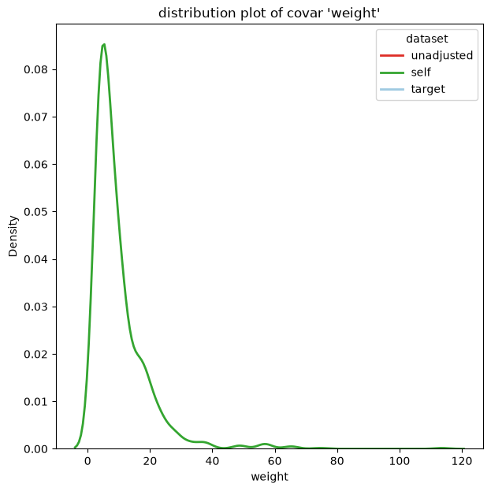

```python
adjusted.weights().plot()
```

```python
print(adjusted.weights().summary().round(2))
```

```
                                var       val
0                     design_effect      1.88
1       effective_sample_proportion      0.53
2             effective_sample_size    531.92
3                               sum  10000.00
4                    describe_count   1000.00
5                     describe_mean      1.00
6                      describe_std      0.94
7                      describe_min      0.30
8                      describe_25%      0.45
9                      describe_50%      0.65
10                     describe_75%      1.17
11                     describe_max     11.36
12                    prop(w < 0.1)      0.00
13                    prop(w < 0.2)      0.00
14                  prop(w < 0.333)      0.11
15                    prop(w < 0.5)      0.32
16                      prop(w < 1)      0.67
17                     prop(w >= 1)      0.33
18                     prop(w >= 2)      0.10
19                     prop(w >= 3)      0.03
20                     prop(w >= 5)      0.01
21                    prop(w >= 10)      0.00
22               nonparametric_skew      0.37
23  weighted_median_breakdown_point      0.21
```

### Design effect and effective sample size

The new API exposes design effect diagnostics through the weights view: `adjusted.weights().design_effect()` and `adjusted.weights().design_effect_prop()`.

```python
print(f"Design effect:           {adjusted.weights().design_effect():.4f}")
print(f"Effective sample size %: {adjusted.weights().design_effect_prop():.2%}")
```

```
Design effect:           1.8800
Effective sample size %: 88.00%
```

## Outcome analysis

```python
print(adjusted.outcomes().summary())
```

```
1 outcomes: ['happiness']
Mean outcomes (with 95% confidence intervals):
source       self  target  unadjusted           self_ci         target_ci     unadjusted_ci
happiness  53.295  56.278      48.559  (52.096, 54.495)  (55.961, 56.595)  (47.669, 49.449)

Weights impact on outcomes (t_test):
           mean_yw0  mean_yw1  mean_diff  diff_ci_lower  diff_ci_upper  t_stat  p_value       n
outcome
happiness    48.559    53.295      4.736          1.312          8.161   2.714    0.007  1000.0

Response rates (relative to number of respondents in sample):
   happiness
n     1000.0
%      100.0
Response rates (relative to notnull rows in the target):
    happiness
n     1000.0
%       10.0
Response rates (in the target):
    happiness
n    10000.0
%      100.0
```

```python
adjusted.outcomes().plot()
```

### Analytics via BalanceDF views

The new API accesses analytics through the `.covars()`, `.weights()`, and `.outcomes()` views rather than top-level convenience methods:

```python
print("Covariate means (unadjusted / adjusted / target):")
print(adjusted.covars().mean().T)
```

```
Covariate means (unadjusted / adjusted / target):
```

```
source                      self     target  unadjusted
_is_na_gender[T.True]   0.086776   0.089800    0.088000
age_group[T.25-34]      0.307355   0.297400    0.300000
age_group[T.35-44]      0.273609   0.299200    0.156000
age_group[T.45+]        0.137581   0.206300    0.053000
gender[Female]          0.406337   0.455100    0.268000
gender[Male]            0.506887   0.455100    0.644000
gender[_NA]             0.086776   0.089800    0.088000
income                 10.060068  12.737608    6.297302
```

```python
print("Outcome SD proportional change:")
print(adjusted.outcomes().outcome_sd_prop())
print()
print("Outcome variance ratio (adjusted / unadjusted):")
print(adjusted.outcomes().outcome_variance_ratio())
```

```
Outcome SD proportional change:
happiness    0.013516
dtype: float64

Outcome variance ratio (adjusted / unadjusted):
happiness    1.027215
dtype: float64
```

## Other Adjustment Methods

BalanceFrame supports all the same methods as Sample:

- `"ipw"` — inverse propensity weighting (default)
- `"cbps"` — covariate balancing propensity score
- `"rake"` — iterative proportional fitting (raking)
- `"poststratify"` — post-stratification

Each returns a **new** BalanceFrame — the original stays unchanged.

```python
adjusted_cbps = bf.adjust(method="cbps")
print(f"CBPS design effect: {adjusted_cbps.weights().design_effect():.4f}")
print(adjusted_cbps.covars().asmd(aggregate_by_main_covar=True).T)
```

```
INFO (2026-09-21 04:48:36,709) [cbps/cbps (line 535)]: Starting cbps function
```

```
INFO (2026-09-21 04:48:36,711) [adjustment/apply_transformations (line 438)]: Adding the variables: []
```

```
INFO (2026-09-21 04:48:36,711) [adjustment/apply_transformations (line 439)]: Transforming the variables: ['gender', 'age_group', 'income']
```

```
INFO (2026-09-21 04:48:36,719) [adjustment/apply_transformations (line 475)]: Final variables in output: ['gender', 'age_group', 'income']
```

```
INFO (2026-09-21 04:48:36,838) [cbps/cbps (line 586)]: The formula used to build the model matrix: ['income + gender + age_group + _is_na_gender']
```

```
INFO (2026-09-21 04:48:36,839) [cbps/cbps (line 597)]: The number of columns in the model matrix: 16
```

```
INFO (2026-09-21 04:48:36,840) [cbps/cbps (line 598)]: The number of rows in the model matrix: 11000
```

```
INFO (2026-09-21 04:48:36,847) [cbps/cbps (line 666)]: Finding initial estimator for GMM optimization
```

```
INFO (2026-09-21 04:48:36,975) [cbps/cbps (line 693)]: Finding initial estimator for GMM optimization that minimizes the balance loss
```

```
INFO (2026-09-21 04:48:38,421) [cbps/cbps (line 729)]: Running GMM optimization
```

```
INFO (2026-09-21 04:48:40,090) [cbps/cbps (line 880)]: Done cbps function
```

```
CBPS design effect: 2.7543
source          self  unadjusted  unadjusted - self
age_group   0.064140    0.232409           0.168269
gender      0.044220    0.253769           0.209549
income      0.113017    0.494217           0.381200
mean(asmd)  0.073792    0.326799           0.253006
```

## Compound / Sequential Adjustments

`adjust()` can be called **multiple times** — each call uses the previously adjusted weights as design weights, so adjustments compound. This is useful for multi-step workflows, e.g., IPW for broad correction followed by raking for fine-tuning on specific variables.

The original unadjusted baseline is always preserved:

- `_sf_sample_pre_adjust` points to the **original** SampleFrame
- `_links["unadjusted"]` points to the **original** BalanceFrame
- `asmd_improvement()` shows **total** improvement across all steps

```python
# Step 1: broad IPW correction across all covariates
adjusted_ipw = bf.adjust(method="ipw", max_de=2)

# Step 2: fine-tune with raking on gender and age_group
adjusted_final = adjusted_ipw.adjust(method="rake", variables=["gender", "age_group"])

print("After IPW only:")
print(adjusted_ipw.covars().asmd(aggregate_by_main_covar=True).T)
print("\nAfter IPW + rake on gender & age_group:")
print(adjusted_final.covars().asmd(aggregate_by_main_covar=True).T)
print(f"\nTotal ASMD improvement (vs original): {adjusted_final.covars().asmd_improvement():.2%}")

# The original BalanceFrame is unchanged (immutable pattern)
print(f"\nbf.is_adjusted = {bf.is_adjusted}")
print(f"adjusted_final.is_adjusted = {adjusted_final.is_adjusted}")
```

```
INFO (2026-09-21 04:48:40,238) [ipw/ipw (line 734)]: Starting ipw function
```

```
INFO (2026-09-21 04:48:40,242) [adjustment/apply_transformations (line 438)]: Adding the variables: []
```

```
INFO (2026-09-21 04:48:40,243) [adjustment/apply_transformations (line 439)]: Transforming the variables: ['gender', 'age_group', 'income']
```

```
INFO (2026-09-21 04:48:40,250) [adjustment/apply_transformations (line 475)]: Final variables in output: ['gender', 'age_group', 'income']
```

```
INFO (2026-09-21 04:48:40,368) [ipw/ipw (line 811)]: Building model matrix
```

```
INFO (2026-09-21 04:48:40,369) [ipw/ipw (line 812)]: The formula used to build the model matrix: ['income + gender + age_group + _is_na_gender']
```

```
INFO (2026-09-21 04:48:40,369) [ipw/ipw (line 813)]: The number of columns in the model matrix: 16
```

```
INFO (2026-09-21 04:48:40,370) [ipw/ipw (line 814)]: The number of rows in the model matrix: 11000
```

```
INFO (2026-09-21 04:48:42,171) [ipw/ipw (line 1016)]: Done with sklearn
```

```
INFO (2026-09-21 04:48:42,172) [ipw/ipw (line 1018)]: max_de: 2
```

```
INFO (2026-09-21 04:48:42,172) [ipw/choose_regularization (line 379)]: Starting choosing regularisation parameters
```

```
INFO (2026-09-21 04:48:50,826) [ipw/choose_regularization (line 465)]: Best regularisation:
           s  s_index  trim  design_effect  asmd_improvement     asmd
9  0.009726      125   5.0       1.998665          0.711052  0.05646
```

```
INFO (2026-09-21 04:48:50,829) [ipw/ipw (line 1096)]: Chosen lambda: 0.009726392859944848
```

```
INFO (2026-09-21 04:48:50,830) [ipw/ipw (line 1113)]: Proportion null deviance explained 0.18189302029172694
```

```
INFO (2026-09-21 04:48:50,839) [adjustment/apply_transformations (line 438)]: Adding the variables: []
```

```
INFO (2026-09-21 04:48:50,840) [adjustment/apply_transformations (line 439)]: Transforming the variables: ['gender', 'age_group']
```

```
INFO (2026-09-21 04:48:50,844) [adjustment/apply_transformations (line 475)]: Final variables in output: ['gender', 'age_group']
```

```
INFO (2026-09-21 04:48:50,851) [rake/rake (line 627)]: Final covariates and levels that will be used in raking: {'age_group': ['18-24', '25-34', '35-44', '45+'], 'gender': ['Female', 'Male', '__NaN__']}.
```

```
After IPW only:
source          self  unadjusted  unadjusted - self
age_group   0.071234    0.232409           0.161175
gender      0.059885    0.253769           0.193884
income      0.189626    0.494217           0.304591
mean(asmd)  0.106915    0.326799           0.219883

After IPW + rake on gender & age_group:
```

```
source              self  unadjusted  unadjusted - self
age_group   1.314723e-04    0.232409           0.232278
gender      7.431140e-17    0.253769           0.253769
income      2.145267e-01    0.494217           0.279690
mean(asmd)  7.155273e-02    0.326799           0.255246

Total ASMD improvement (vs original): 78.10%

bf.is_adjusted = False
adjusted_final.is_adjusted = True
```

## Transformations

Transformations (one-hot encoding, interaction terms, etc.) are applied automatically during `adjust()`. You can also pass custom `transformations` via kwargs. To inspect the transformed design matrix, use `model_matrix()`.

```python
# Inspect the model matrix (transformed covariates) used during adjustment
print("Transformed covariates columns:")
print(adjusted.model_matrix().columns.tolist())
```

```
Transformed covariates columns:
['_is_na_gender[T.True]', 'age_group[T.25-34]', 'age_group[T.35-44]', 'age_group[T.45+]', 'gender[Female]', 'gender[Male]', 'gender[_NA]', 'income']
```

## Diagnostics

`diagnostics()` returns a DataFrame with bias metrics per covariate.

```python
print(adjusted.diagnostics().to_string())
```

```
INFO (2026-09-21 04:48:51,271) [balance_frame/diagnostics (line 3902)]: Starting computation of diagnostics of the fitting
```

```
INFO (2026-09-21 04:48:51,562) [balance_frame/diagnostics (line 3929)]: Done computing diagnostics
```

```
                                      metric           val                                                             var
0                                       size   1000.000000                                                      sample_obs
1                                       size      3.000000                                                   sample_covars
2                                       size  10000.000000                                                      target_obs
3                                       size      3.000000                                                   target_covars
4                        weights_diagnostics      1.879989                                                   design_effect
5                        weights_diagnostics      0.531918                                     effective_sample_proportion
6                        weights_diagnostics    531.918146                                           effective_sample_size
7                        weights_diagnostics  10000.000000                                                             sum
8                        weights_diagnostics   1000.000000                                                  describe_count
9                        weights_diagnostics      1.000000                                                   describe_mean
10                       weights_diagnostics      0.938546                                                    describe_std
11                       weights_diagnostics      0.304163                                                    describe_min
12                       weights_diagnostics      0.445457                                                    describe_25%
13                       weights_diagnostics      0.653173                                                    describe_50%
```

[output cut: 92 more lines]

## Exporting results

The `.df` property returns the responder DataFrame with id, covariates, outcomes, weights, and any ignored columns. Use `.to_csv()` to export the adjusted data.

```python
print("Adjusted DataFrame columns:", adjusted.df.columns.tolist())
print(adjusted.df.head())
```

```
Adjusted DataFrame columns: ['id', 'gender', 'age_group', 'income', 'happiness', 'weight']
  id  gender age_group     income  happiness    weight
0  0    Male     25-34   6.428659  26.043029  6.531728
1  1  Female     18-24   9.940280  66.885485  9.617159
2  2    Male     18-24   2.673623  37.091922  3.562973
3  3     NaN     18-24  10.550308  49.394050  6.952117
4  4     NaN     18-24   2.689994  72.304208  5.129230
```

```python
# Export to CSV (showing first 500 characters)
print(adjusted.to_csv()[:500])
```

```
id,gender,age_group,income,happiness,weight
0,Male,25-34,6.428659499046228,26.043028759747298,6.531727983159214
1,Female,18-24,9.940280228116047,66.88548460632677,9.617159404461365
2,Male,18-24,2.6736231547518043,37.091921916683006,3.562973405562926
3,,18-24,10.550307519418066,49.39405003271002,6.952116676608549
4,,18-24,2.689993854299385,72.30420755038209,5.1292302114666075
5,,35-44,5.995497722733131,57.28281646341816,16.424761754946537
6,,18-24,12.63469573898972,31.663293445944596,8.1911333259
```

```python
adjusted.to_download()
```

Click here to download: /tmp/tmp_balance_out_62d0c07c-55ae-4e1f-bf27-6a357be29d1e.csv

## Filtering rows/columns

`keep_only_some_rows_columns()` returns a new BalanceFrame with filtered data — the original remains unchanged (immutable pattern).

```python
filtered = adjusted.keep_only_some_rows_columns(
    rows_to_keep="gender == 'Female'",
    columns_to_keep=["gender", "age", "income"],
)
print(f"Original rows: {len(adjusted.responders)}")
print(f"Filtered rows: {len(filtered.responders)}")
print(filtered.df.head())
```

```
INFO (2026-09-21 04:48:51,605) [balance_frame/_filter_sf (line 4154)]: (rows_filtered/total_rows) = (268/1000)
```

```
INFO (2026-09-21 04:48:51,607) [balance_frame/_filter_sf (line 4154)]: (rows_filtered/total_rows) = (4551/10000)
```

```
INFO (2026-09-21 04:48:51,609) [balance_frame/_filter_sf (line 4154)]: (rows_filtered/total_rows) = (268/1000)
```

```
INFO (2026-09-21 04:48:51,611) [balance_frame/_filter_sf (line 4154)]: (rows_filtered/total_rows) = (268/268)
```

```
INFO (2026-09-21 04:48:51,613) [balance_frame/_filter_sf (line 4154)]: (rows_filtered/total_rows) = (4551/4551)
```

```
INFO (2026-09-21 04:48:51,615) [balance_frame/_filter_sf (line 4154)]: (rows_filtered/total_rows) = (268/268)
```

```
Original rows: 1000
Filtered rows: 268
   id  gender     income  happiness     weight
0   1  Female   9.940280  66.885485   9.617159
1  92  Female   0.185097  84.464522  17.392266
2  94  Female   1.183696  65.742184  17.794007
3  95  Female   3.716007  67.624539   7.283279
4  98  Female  16.751931  44.868651  48.725241
```

## Summary: Old vs New API side-by-side

| Step | Old API (`Sample`) | New API (`SampleFrame` / `BalanceFrame`) |
| --- | --- | --- |
| Load data | `s = Sample.from_frame(df)` | `sf = SampleFrame.from_frame(df)` |
| Pair sample + target | `s.set_target(target)` | `bf = BalanceFrame(sample=sf, target=target_sf)` |
| Adjust | `adjusted = s.adjust()` *(mutates s)* | `adjusted = bf.adjust()` *(bf unchanged)* |
| Summary | `adjusted.summary()` | `adjusted.summary()` |
| Diagnostics | `adjusted.diagnostics()` | `adjusted.diagnostics()` |
| Covariates | `adjusted.covars().mean()` | `adjusted.covars().mean()` |
| Design effect | `adjusted.design_effect()` | `adjusted.weights().design_effect()` |
| CSV export | `adjusted.to_csv()` | `adjusted.to_csv()` |
| Filter | *(not available)* | `adjusted.keep_only_some_rows_columns(...)` |